# Third Week: Exploratory Data Analysis

LaLiga Analysis

Erfan Hosseini _ 93101373

2018-02-26 19:21:48

# تمرین سری سوم: از لالیگا تا لیگ برتر

> با استفاده از داده های لیگ دسته اول اسپانیا به سوالات زیر پاسخ دهید. از هر دو ابزار ggplot2 و highcharter برای این کار تصویرسازی استفاده نمایید.

۱. تعداد قهرمانی های تیم ها در تاریخ لالیگا را استخراج کرده و نمودار ستونی آنها را رسم کنید.

```r
data('spain')
spain %>% filter(tier == 1) %>% select(1:10) -> spain
rbind(
    spain %>% select(Season, team = home, opp= visitor, GF = hgoal, GA = vgoal),
    spain %>% select(Season, team = visitor, opp= home, GF = vgoal, GA = hgoal)
) %>% mutate(GD = GF - GA) %>%
    group_by(Season, team) %>% summarise(goalF = sum(GF), goalA = sum(GA), gamesPlayed = n(), W = sum(GD > 0), D = sum(GD == 0), L = sum(GD < 0)) %>%
    mutate(points = 3*W + D, goalDiff = goalF - goalA) -> res
res %>% arrange(Season, desc(points), desc(goalDiff), desc(goalF)) %>% mutate(rank = row_number()) -> winTables
winTables %>% filter(rank == 1) %>% group_by(team) %>% summarise(numWin = n()) %>% arrange(desc(numWin)) -> champs
winTables %>% filter(rank == 1) %>% select(Season, champ = team) ->wholeChamps
champs$team <- factor(champs$team, levels = champs$team)
```

نمودار توسط ggplot به صورت زیر است :

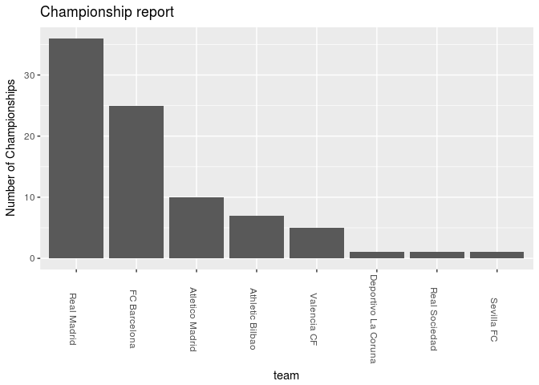

```r
p = ggplot(data = champs, aes(x = team, y = numWin))
p + geom_bar(stat = 'identity') + theme(axis.text.x = element_text(angle = 270)) + ggtitle('Championship report') + ylab('Number of Championships')
```

نمودار توسط highcharter به صورت زیر است :

```r
hchart(champs, hcaes(x = team, y= numWin), type = 'column') %>%  hc_yAxis(title = list(text = 'Championship report')) %>% hc_title(text= 'Championship report')
```

[interactive chart not shown]

۲. کسل کننده ترین لیگ و تیم را بیابید. نمودار ده تیم و ده فصل کسل کننده را رسم کنید.

```r
res %>% group_by(team) %>% summarise(avgFgoal = mean(goalF)) %>% arrange(avgFgoal)  -> sumTeam
sumTeam %>% head(10) -> sumTeam
sumTeam$team <- factor(sumTeam$team, levels = sumTeam$team)
```

نمودار کسلیتی هر تیم توسط ggplot بصورت زیر است:(کسلیتی پایین نشان دهنده این است که تیم کسل کننده تر است.)

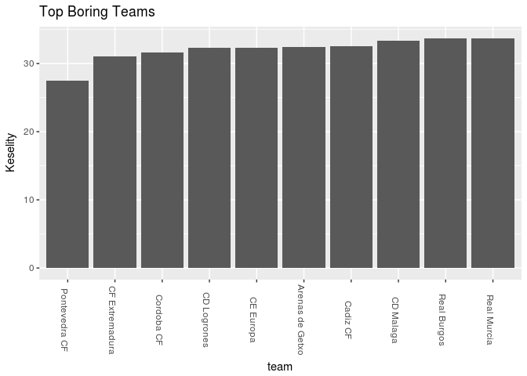

```r
p = ggplot(data = sumTeam, aes(x = team, y= avgFgoal))
p + geom_bar(stat = 'identity') + ylab('Keselity') + ggtitle('Top Boring Teams')+ theme(axis.text.x = element_text(angle = 270))
```

همین نمودار توسط highcharter :

```r
hchart(sumTeam, hcaes(x = team, y= avgFgoal), type = 'bar') %>% hc_yAxis(title = list(text = 'Keselity')) %>%
    hc_title(text= 'Top boring Teams') %>% hc_xAxis(title = list(text = 'Team'))
```

[interactive chart not shown]

همانطور که دیده می شود تیم Pontevedra CF کسل کننده ترین تیم می باشد.

نمودار کسلیتی فصل ها توسط ggplot بصورت زیر است:

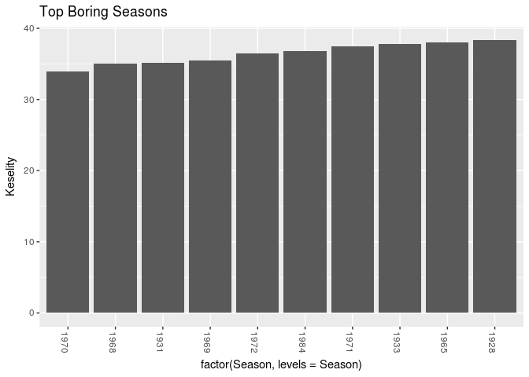

```r
res %>% group_by(Season) %>% summarise(keselity = mean(goalF) ) %>% arrange(keselity) %>% head(10)-> sumSea
p = ggplot(data = sumSea, aes(x = factor(Season, levels = Season), y= keselity))
p + geom_bar(stat = 'identity') + ylab('Keselity') + ggtitle('Top Boring Seasons')+ theme(axis.text.x = element_text(angle = 270))
```

همین نمودار توسط highcharter :

```r
hchart(sumSea, hcaes(x = factor(Season), y= keselity), type = 'bar') %>% hc_yAxis(title = list(text = 'Keselity')) %>%
    hc_title(text= 'Top boring Seasons') %>% hc_xAxis(title = list(text = 'Team'))
```

[interactive chart not shown]

همانطور که دیده می شود فصل ۱۹۷۰ کسل کننده ترین فصل در این معیار می باشد.

۳. در چند درصد موارد قهرمان نیم فصل در پایان فصل قهرمان شده است؟

```r
spain %>% filter(tier ==1) %>% group_by(Season) %>% slice(1:(n()/2)) -> halfSeason
rbind(
    halfSeason %>% select(Season, team = home, opp= visitor, GF = hgoal, GA = vgoal),
    halfSeason %>% select(Season, team = visitor, opp= home, GF = vgoal, GA = hgoal)
) %>% mutate(GD = GF - GA) %>%
    group_by(Season, team) %>% summarise(goalF = sum(GF), goalA = sum(GA), gamesPlayed = n(), W = sum(GD > 0), D = sum(GD == 0), L = sum(GD < 0)) %>%
    mutate(points = 3*W + D, goalDiff = goalF - goalA) -> resHalf
resHalf %>% arrange(Season, desc(points), desc(goalDiff), desc(goalF)) %>% mutate(rank = row_number()) -> winTablesHalf
winTablesHalf %>% filter(rank==1) %>% select(Season, halfChamp = team) -> halfChamps
full_join(halfChamps, wholeChamps) %>% mutate(ok = (halfChamp == champ)) -> champRep
print(sum(champRep$ok) / nrow(champRep) * 100)
```

```
## [1] 52.32558
```

۴. در بین سال های ۲۰۰۱ تا ۲۰۱۰ گربه سیاه تیم های بزرگ چه تیم هایی بوده است؟

در کد زیر ۲ گربه سیاه برای بارسلونا محاسبه می شود :

```r
rbind(
    spain %>% filter(home == 'FC Barcelona') %>% select(Season, team1 = visitor, hgoal, vgoal) %>%
        mutate(result = vgoal > hgoal),
    spain %>% filter(visitor == 'FC Barcelona') %>% select(Season, team1 = home, hgoal, vgoal) %>%
        mutate(result = vgoal < hgoal)
) %>% select(Season, team = team1, won= result) %>% filter((won == TRUE) & (Season >= 2001) & (Season <= 2010)) -> aBarca
aBarca %>% group_by(team) %>% summarise(count = n()) %>% arrange(desc(count)) -> aBarcaRep
winTables %>% filter(Season>= 2001 & Season<= 2010) %>% group_by(team) %>% summarise(meanRank = mean(rank)) -> rankRep
barcaRank = filter(rankRep, team=='FC Barcelona')
barcaRank = barcaRank$meanRank
full_join(rankRep, aBarcaRep) %>% na.omit() %>% arrange(desc(count)) -> aBarcaRep
aBarcaRep %>% filter(meanRank >= (barcaRank+6)) %>% filter(count >= 3) %>% head(3) -> barcaBC
barcaBC %>% head(2) -> a
print(a$team)
```

```
## [1] "Deportivo La Coruna" "Real Betis"
```

در کد زیر ۲ گربه سیاه برای رئال مادرید محاسبه می شود :

```r
rbind(
    spain %>% filter(home == 'Real Madrid') %>% select(Season, team1 = visitor, hgoal, vgoal) %>%
        mutate(result = vgoal > hgoal),
    spain %>% filter(visitor == 'Real Madrid') %>% select(Season, team1 = home, hgoal, vgoal) %>%
        mutate(result = vgoal < hgoal)
) %>% select(Season, team = team1, won= result) %>% filter((won == TRUE) & (Season >= 2001) & (Season <= 2010)) -> aReal
aReal %>% group_by(team) %>% summarise(count = n()) %>% arrange(desc(count)) -> aRealRep
realRank = filter(rankRep, team=='Real Madrid')
realRank = realRank$meanRank
full_join(rankRep, aRealRep) %>% na.omit() %>% arrange(desc(count)) -> aRealRep
aRealRep %>% filter(meanRank >= (realRank+6)) %>% filter(count >= 3) %>% head(2)-> realBC
print(realBC$team)
```

```
## [1] "Deportivo La Coruna" "Athletic Bilbao"
```

در کد زیر ۲ گربه سیاه برای والنسیا محاسبه می شود :

```r
rbind(
    spain %>% filter(home == 'Valencia CF') %>% select(Season, team1 = visitor, hgoal, vgoal) %>%
        mutate(result = vgoal > hgoal),
    spain %>% filter(visitor == 'Valencia CF') %>% select(Season, team1 = home, hgoal, vgoal) %>%
        mutate(result = vgoal < hgoal)
) %>% select(Season, team = team1, won= result) %>% filter((won == TRUE) & (Season >= 2001) & (Season <= 2010)) -> aVal
aVal %>% group_by(team) %>% summarise(count = n()) %>% arrange(desc(count)) -> aValRep
valRank = filter(rankRep, team=='Valencia CF')
valRank = valRank$meanRank
full_join(rankRep, aValRep) %>% na.omit() %>% arrange(desc(count)) -> aValRep
aValRep %>% filter(meanRank >= (valRank+6)) %>% filter(count >= 3) %>% head(2)-> valBC
print(valBC$team)
```

```
## [1] "Racing Santander" "CA Osasuna"
```

۵. در تاریخ لالیگا کدام تیم رکورددار زودترین قهرمانی است؟ همچنین کدام تیم مقتدرانه ترین قهرمانی را داشته است؟

```r
spain %>% select(Season) %>% distinct() -> season
wholeChamps %>% mutate(remTimeChamp = 0 ) -> statChamp
winTables %>% group_by(Season) %>% slice(which.max(rank)) -> tmp
tmp %>% select(Season, Fall = team) %>% mutate(remTimeFall = 0) -> statFall
analyse = function(played){
    out = crtLeague
    for(i in 1:nrow(played)){
        pox = played[i,]
        team = pox$team
        date = pox$Date
        out$GD[which(out$team == team & out$date == date)] = out$GD[which(out$team == team & out$date == date)] + pox$GD
        out$GF[which(out$team == team & out$date == date)] = out$GF[which(out$team == team & out$date == date)] + pox$GF
        out$gamesPlayed[which(out$team == team & out$date == date)] = out$gamesPlayed[which(out$team == team & out$date == date)] + 1
        if(pox$GF > pox$GA){
            out$point[which(out$team == team & out$date == date)] = out$point[which(out$team == team & out$date == date)] + 3
        }
        if(pox$GF == pox$GA){
            out$point[which(out$team == team & out$date == date)] = out$point[which(out$team == team & out$date == date)] + 1
        }
    }
    crtLeague <<- out
}
for( i in 1:nrow(wholeChamps)){

    crtSeason = wholeChamps$Season[i]
    spain %>% filter(Season == crtSeason) %>% select(team = home) %>% distinct() -> crtTeams
    spain %>% filter(Season == crtSeason) %>% select(Date) %>% distinct() -> crtDates
    crtLeague = data.frame(colnames(c('date', 'team')))
    for( j in crtDates$Date){
        crtLeague = rbind(crtLeague, crtTeams %>% mutate(date = as.Date(j)))
    }
    crtLeague %>% mutate(point = 0, GD=0, GF=0, gamesPlayed=0) -> crtLeague
    spain %>% filter(Season == crtSeason) -> s
    rbind(
        s %>% select(Season,Date, team = home, opp= visitor, GF = hgoal, GA = vgoal),
        s %>% select(Season,Date,  team = visitor, opp= home, GF = vgoal, GA = hgoal)
    ) %>% mutate(GD = GF - GA) %>% arrange(Date) -> s
    s %>% group_by(Date) %>% analyse()
    crtLeague %>% group_by(team) %>% mutate(point = cumsum(point), GD = cumsum(GD), GF = cumsum(GF), gamesPlayed = cumsum(gamesPlayed)) -> crtLeague
    crtLeague %>% group_by(date) %>% arrange(date,desc(point), desc(GD), desc(GF)) %>% mutate(rank = row_number()) -> crtLeague
    crtLeague %>% group_by(date) %>% mutate(dRank = max(crtLeague$rank) - rank + 1)  -> crtLeague
    crtLeague %>% filter(rank == 1) %>% select(firstTeam = team, date, firstPoint = point, firstGamesPlayed = gamesPlayed) -> crtFirst
    crtLeague %>% filter(rank == 2) %>% select(secTeam = team, date, secPoint = point, secGamesPlayed = gamesPlayed) -> crtSec
    crtLeague %>% filter(dRank == 1) %>% select(lastTeam = team, date, lastPoint = point, lastGamesPlayed = gamesPlayed) -> crtLast
    crtLeague %>% filter(dRank == 4) %>% select(last4Team = team, date, last4Point = point, last4GamesPlayed = gamesPlayed) -> crt4Last

    crtRep = full_join(full_join(full_join(crtFirst, crtSec), crt4Last), crtLast)
    crtRep %>%
        mutate(firstGamesRem = max(crtRep$firstGamesPlayed) - firstGamesPlayed,
               secGamesRem = max(crtRep$secGamesPlayed) - secGamesPlayed,
               firstdPoint = firstPoint-secPoint,
               lastdPoint = last4Point - lastPoint,
               lastGamesRem = max(crtRep$lastGamesPlayed) - lastGamesPlayed,
               last4GamesRem = max(crtRep$last4GamesPlayed) - last4GamesPlayed) %>%
        select(date,
               firstTeam = firstTeam,
               lastTeam = lastTeam,
               firstdPoint,
               lastdPoint,
               firstGamesRem,
               secGamesRem,
               lastGamesRem,
               last4GamesRem)-> crtRep
    crtRep %>% mutate(champObv = (firstdPoint > secGamesRem*3)) -> crtRep
    crtRep %>% mutate(fallObv = (lastdPoint > lastGamesRem*3)) -> crtRep
    remChamp = max(crtRep$firstGamesRem[which(crtRep$champObv)])
    remFall = max(crtRep$lastGamesRem[which(crtRep$fallObv)])
    statChamp$remTimeChamp[i] = remChamp
    statFall$remTimeFall[i] = remFall
}
statChamp %>% arrange(desc(remTimeChamp)) -> statChamp
statFall %>% arrange(desc(remTimeFall)) -> statFall
```

```r
print(statChamp[which(statChamp$remTimeChamp == max(statChamp$remTimeChamp)),])
```

```
## # A tibble: 5 x 3
## # Groups:   Season [5]
##   Season champ        remTimeChamp
##    <dbl> <chr>               <dbl>
## 1   1960 Real Madrid          5.00
## 2   1962 Real Madrid          5.00
## 3   1973 FC Barcelona         5.00
## 4   1974 Real Madrid          5.00
## 5   1990 FC Barcelona         5.00
```

همانطور که دیده می شود تیم رئال مادرید در سال های ۱۹۶۰ و ۱۹۶۲ و ۱۹۷۴ و تیم بارسلونا در سال های ۱۹۷۳و ۱۹۹۰ در ۵ هفته به پایان لیگ به قهرمانی رسیده اند.

در زیر مقتدرانه ترین قهرمانی با معیار زودتر مشخص شدن قهرمانی و بالا بودن اختلاف امتیاز با نفر دوم محاسبه می شود :

```r
statChamp[which(statChamp$remTimeChamp == max(statChamp$remTimeChamp)),] %>% select(Season, team = champ) -> fastChamp
fastChamp$D = 0
for(i in fastChamp$Season){
    winTables %>% filter(rank==1, Season == i) -> pox1
    winTables %>% filter(rank==2, Season == i) -> pox2
    fastChamp$D[which(fastChamp$Season == i)] = pox1$points - pox2$points
}
bestChamp = fastChamp[which.max(fastChamp$D),]
print(bestChamp)
```

```
## # A tibble: 1 x 3
## # Groups:   Season [1]
##   Season team            D
##    <dbl> <chr>       <dbl>
## 1   1962 Real Madrid  21.0
```

بنابر نتیجه بالا رئال در سال ۱۹۶۲ با اختلاف امتیاز ۲۱ عنوان مقتدرانه ترین قهرمانی را کسب می کند.

۶. طولانی ترین نوار پیروزی مساوی و شکست مال چه تیم هایی است؟

```r
rbind(
    spain %>% select(Season,Date, team = home, opp= visitor, GF = hgoal, GA = vgoal),
    spain %>% select(Season,Date, team = visitor, opp= home, GF = vgoal, GA = hgoal)
) %>% mutate(result = case_when(GF > GA ~ 'W',
                                GF == GA ~'D',
                                GF < GA ~ 'L')) %>% select(Date, team, result) %>% arrange(team, Date)-> res

streak = function(x, char){
    y = rle(x)
    tmp = y$lengths[y$values == char]
    return(max(tmp))
}

res %>% group_by(team) %>% summarise(winStreak = streak(result,"W")) %>% slice(which(winStreak == max(winStreak))) -> winStreak
res %>% group_by(team) %>% summarise(lossStreak = streak(result,"L")) %>% slice(which(lossStreak == max(lossStreak))) -> lossStreak
res %>% group_by(team) %>% summarise(drawStreak = streak(result,"D")) %>% slice(which(drawStreak == max(drawStreak))) -> drawStreak
```

همانطور که در زیر دیده می شود ۲ تیم رئال و بارسا یا ۱۶برد پیاپی دارای طولانی ترین نوار پیروزی هستند.

```r
print(winStreak)
```

```
## # A tibble: 2 x 2
##   team         winStreak
##   <chr>            <int>
## 1 FC Barcelona        16
## 2 Real Madrid         16
```

همانطور که در زیر دیده می شود تیم لاس پالماس با ۱۱ باخت پیاپی دارای طولانی ترین نوار باخت هستند.ند.

```r
print(lossStreak)
```

```
## # A tibble: 1 x 2
##   team          lossStreak
##   <chr>              <int>
## 1 UD Las Palmas         11
```

همانطور که در زیر دیده می شود تیم burgos CF با ۹ تساوی پیاپی دارای طولانی ترین نوار تساوی هستند.

```r
print(drawStreak)
```

```
## # A tibble: 1 x 2
##   team      drawStreak
##   <chr>          <int>
## 1 Burgos CF          9
```

۷. زودترین سقوط مال کدام تیم بوده است؟

```r
print(statFall[which(statFall$remTimeFall == max(statFall$remTimeFall)),])
```

```
## # A tibble: 1 x 3
## # Groups:   Season [1]
##   Season Fall           remTimeFall
##    <dbl> <chr>                <dbl>
## 1   1997 Sporting Gijon        7.00
```

بنابر محاسیات فوق تیم Sporting Gijon در سال ۱۹۹۷ در ۷ هفتگی پایان فصل سقوط خود را قطعی می کند

```r
library('zoo')
spain %>% filter(Season == 1998) -> s98
rbind(
    s98 %>% select(Season,Date, team = home, opp= visitor, GF = hgoal, GA = vgoal),
    s98 %>% select(Season,Date,  team = visitor, opp= home, GF = vgoal, GA = hgoal)
) %>% mutate(GD = GF - GA) %>% arrange(Date) -> s98
analyse = function(played){
    out = league
    for(i in 1:nrow(played)){
        pox = played[i,]
        team = pox$team
        date = pox$Date
        out$GD[which(out$team == team & out$date == date)] = out$GD[which(out$team == team & out$date == date)] + pox$GD
        out$GF[which(out$team == team & out$date == date)] = out$GF[which(out$team == team & out$date == date)] + pox$GF
        if(pox$GF > pox$GA){
            out$point[which(out$team == team & out$date == date)] = out$point[which(out$team == team & out$date == date)] + 3
        }
        if(pox$GF == pox$GA){
            out$point[which(out$team == team & out$date == date)] = out$point[which(out$team == team & out$date == date)] + 1
        }
    }
    league <<- out
}
s98 %>% select(team) %>% distinct() -> teams
s98 %>% select(Date) %>% distinct() -> dates
league = data.frame(colnames(c('date', 'team')))
for( i in dates$Date){
    league = rbind(league, teams %>% mutate(date = as.Date(i)))
}
league %>% mutate(point = 0, GD=0, GF=0) -> league
s98 %>% group_by(Date) %>% analyse()
league %>% group_by(team) %>% mutate(point = cumsum(point), GD = cumsum(GD), GF = cumsum(GF)) -> league
league %>% group_by(date) %>% arrange(date,desc(point), desc(GD), desc(GF)) %>% mutate(rank = row_number()) -> league
```

نمودار با ggplotبه شکل زیر است :

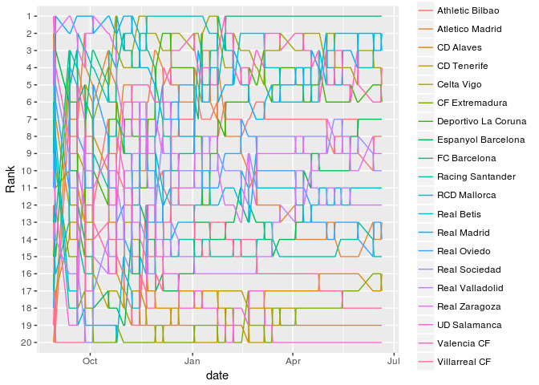

```r
p = ggplot(data = league, aes(x= date, y= reorder(rank, -rank), group = team, colour = team))
p + geom_line() + ylab('Rank')
```

نمودار با highchartبه شکل زیر است :

```r
hchart(league, type = "line", hcaes(x = date, y=rank, group = team))
```

[interactive chart not shown]

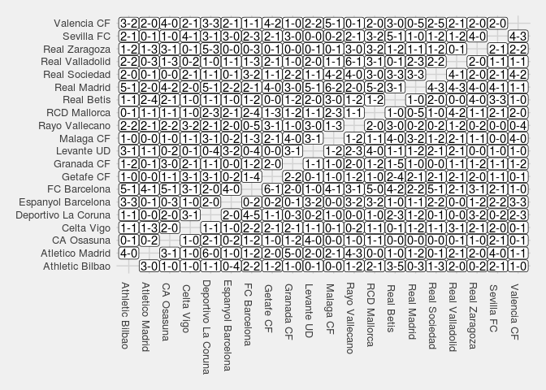

```r
spain %>% filter(Season == 2012) %>% select(home, visitor, FT) -> res
p = ggplot(data = res, aes(x=visitor, y= home)) + theme_fivethirtyeight()
p + geom_label(stat = 'identity', aes(label = FT), label.padding = unit(0.1, 'lines'))+ theme(axis.text.x = element_text(angle=-90, hjust=0.1))
```

۱۰. سه آماره به همراه نمودار فردوسی پسند استخراج کنید.

در نمودار اول اختلاف امتیاز قهرمان هر فصل با تیم دوم کشیده شده است.

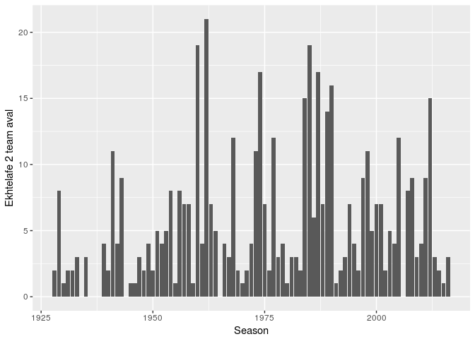

```r
winTables %>% filter(rank ==1 | rank == 2) -> leagueRep
winTables %>% group_by(Season) %>% summarise(champ = team[1], diff = points[1] - points[2]) %>% arrange(desc(diff)) -> champRep
ggplot(data = champRep, aes(x = Season, y= diff)) + geom_bar(stat = 'identity' ) + ylab('Ekhtelafe 2 team aval')
```

```r
hchart(champRep, hcaes(x = Season, y= diff), type='column') %>% hc_yAxis(title = list(text = 'Ekhtelafe 2 team aval'))
```

[interactive chart not shown]

همانطور که دیده می شود در سال ۱۹۶۲ رئال مادرید با اختلاف ۲۱ امتیاز قهرمان شده است که همان نتیجه بخش مقتدرانه ترین قهرمانی نیز می باشد.

در نمودار دوم درصد برد بازی های خانگی برای هر تیم رسم شده است :

```r
spain %>% mutate(win = hgoal > vgoal) %>% select(Team = home, win) -> homeRes
homeRes %>% group_by(Team) %>% summarise(homeWin = sum(win) / n() *100) %>% arrange(desc(homeWin)) -> homeRes
hchart(homeRes, hcaes(x = Team, y= homeWin), type='bar')%>% hc_yAxis(title = list(text = 'Darsade bord bazi haye khanegi'))
```

[interactive chart not shown]

همانطور که دیده می شود رئال با ۷۷ درصد بیشترین میزان برد بازی های خانگی را دارد.

در نمودار سوم درصد برد بازی های مهمان برای هر تیم کشیده شده است :

```r
spain %>% mutate(win = vgoal > hgoal) %>% select(Team = visitor, win) -> forRes
forRes %>% group_by(Team) %>% summarise(foreignWin = sum(win) / n() *100) %>% arrange(desc(foreignWin)) -> forRes
hchart(forRes, hcaes(x = Team, y= foreignWin), type='bar')%>% hc_yAxis(title = list(text = 'Darsade bord bazi haye Khareji'))
```

[interactive chart not shown]

همانطور که می بینیم رئال با ۴۲ درصد بیشترین میزان برد بازی های خارج از خانه را دارد